# Assignment 2: Monthly Report EXIST July, 2020

#### 2.4.1. Hourly Energy Deficit, Energy Surplus,and Balance Distribution

Hourly energy deficit, energy surplus, and energy balance bar chart can be seen below.

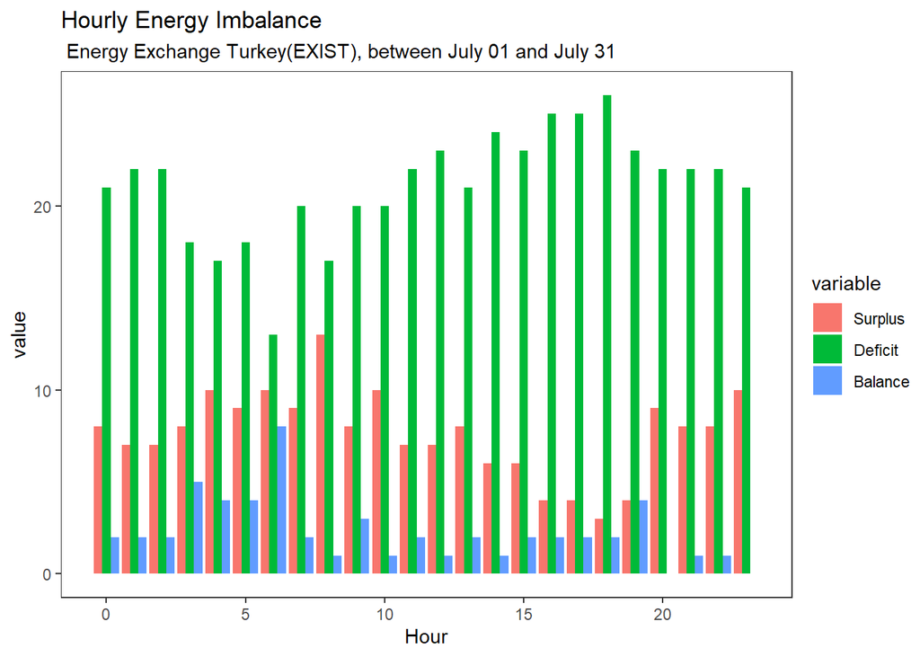

```r
plot14<-EXIST_raw_df %>% group_by(Hour = lubridate::hour(Date))%>%
  summarise(Surplus = sum(MCP>SMP), Deficit=sum(MCP<SMP), Balance=sum(MCP==SMP)) %>% ungroup() %>%
  select(Hour, Surplus, Deficit, Balance)
plot15 <- melt(plot14, id.vars='Hour')
plot15%>%ggplot(.,aes(x=Hour,y=value, fill=variable)) + geom_bar(stat="identity", position="dodge")+theme_test()+
     labs( title=  "Hourly Energy Imbalance",
          subtitle=" Energy Exchange Turkey(EXIST), between July 01 and July 31")
```

#### 2.4.2. Daily Energy Deficit, Energy Surplus,and Balance Distribution

Daily energy deficit, energy surplus, and energy balance bar chart can be seen below.

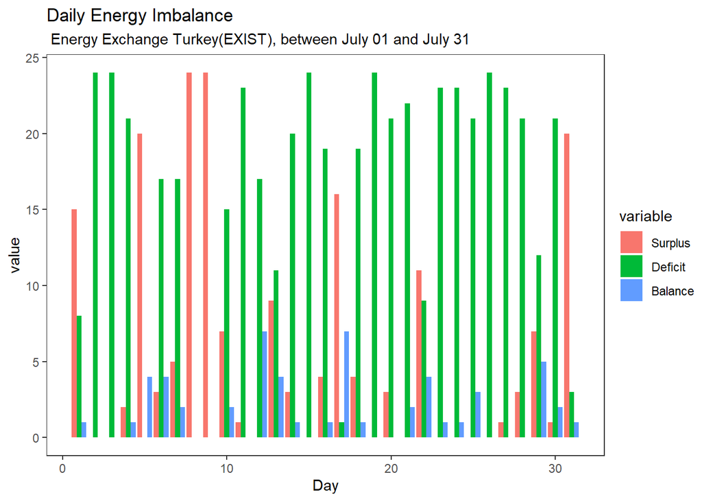

```r
plot12<-EXIST_raw_df %>% group_by(Day = lubridate::day(Date))%>% summarise(Surplus = sum(MCP>SMP), Deficit=sum(MCP<SMP), Balance=sum(MCP==SMP)) %>% ungroup() %>%
select(Day, Surplus, Deficit, Balance)
plot13 <- melt(plot12, id.vars='Day')
plot13%>%ggplot(.,aes(x=Day,y=value, fill=variable)) + geom_bar(stat="identity", position="dodge")+theme_test()+
      labs( title=  "Daily Energy Imbalance",
            subtitle=" Energy Exchange Turkey(EXIST), between July 01 and July 31")
```

#### 2.4.3. Weekly Energy Deficit, Energy Surplus,and Balance Distribution

Weekly energy deficit, energy surplus, and energy balance bar chart can be seen below.Week numbers correspond to the sequence in a year of 52 weeks.

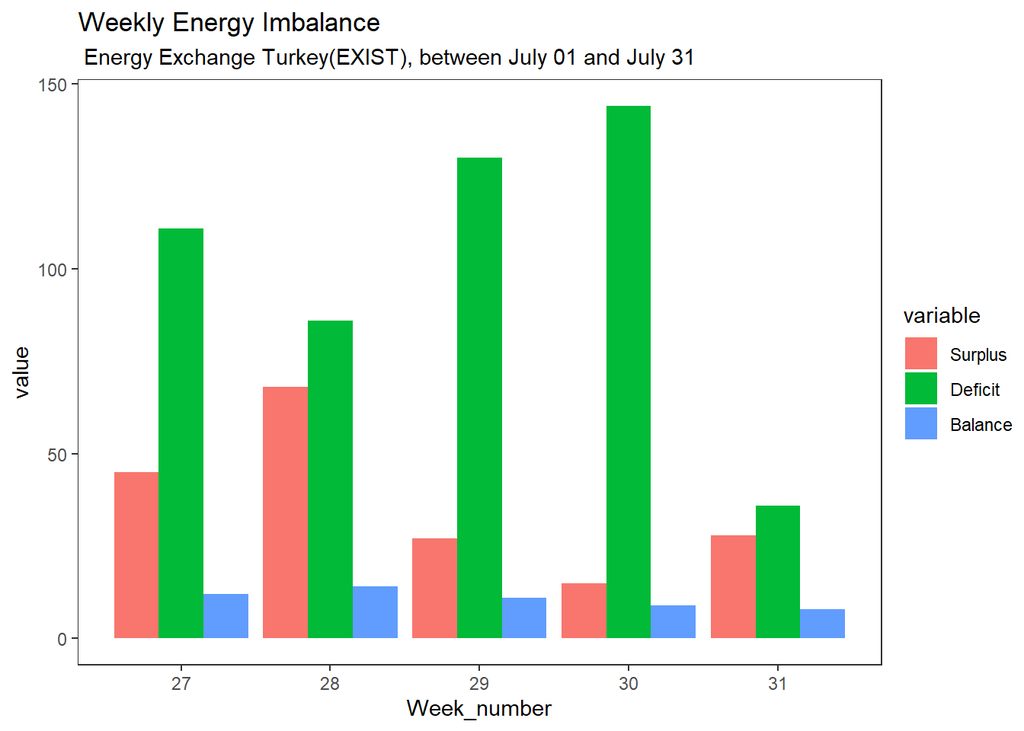

```r
plot16<-EXIST_raw_df %>% group_by(Week_number = lubridate::week(Date))%>%
summarise(Surplus = sum(MCP>SMP), Deficit=sum(MCP<SMP), Balance=sum(MCP==SMP)) %>% ungroup() %>%
select(Week_number, Surplus, Deficit, Balance)
plot17 <- melt(plot16, id.vars='Week_number')
plot17%>%ggplot(.,aes(x=Week_number,y=value, fill=variable)) + geom_bar(stat="identity", position="dodge")+theme_test()+
      labs( title=  "Weekly Energy Imbalance",
            subtitle=" Energy Exchange Turkey(EXIST), between July 01 and July 31")
```

#### 2.4.4. Day of the Week Energy Deficit, Energy Surplus,and Balance Distribution

Energy deficit, energy surplus, and energy balance bar chart according to the day of the week can be seen below.It should be noted that weekday 1 is equal to Sunday.

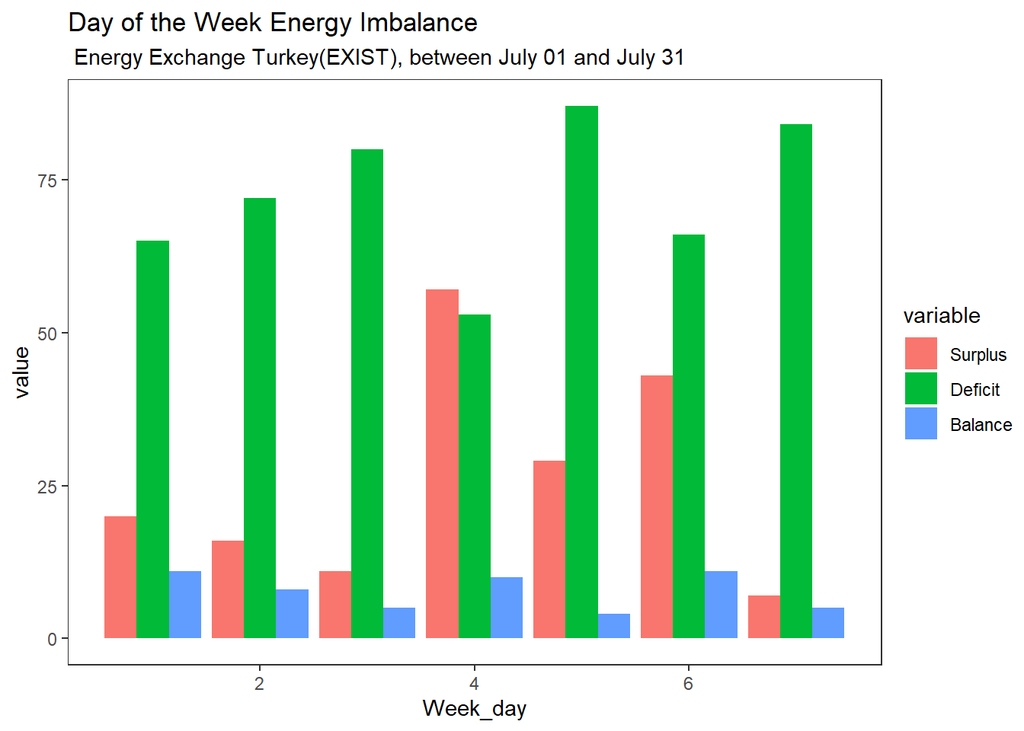

```r
plot18<-EXIST_raw_df %>% group_by(Week_day = lubridate::wday(Date))%>%
  summarise(Surplus = sum(MCP>SMP), Deficit=sum(MCP<SMP), Balance=sum(MCP==SMP)) %>% ungroup() %>%
  select(Week_day, Surplus, Deficit, Balance)
plot19 <- melt(plot18, id.vars='Week_day')
plot19%>%ggplot(.,aes(x=Week_day,y=value, fill=variable)) + geom_bar(stat="identity", position="dodge")+theme_test()+
      labs(title=  "Day of the Week Energy Imbalance",
           subtitle=" Energy Exchange Turkey(EXIST), between July 01 and July 31")
```

## 3. References

[Energy Exchange Turkey Official webpage](https://rapor.epias.com.tr/rapor/xhtml/ptfSmfListeleme.xhtml)